# ps03

```python
import pandas as pd
import numpy as np
import matplotlib.pyplot as plt
from sklearn.model_selection import train_test_split
from sklearn.ensemble import RandomForestClassifier
from sklearn.metrics import accuracy_score
```

## 1

### 1.1

```python
def createData(alpha, beta, nu, n = 1000):
    ## n: number of data points
    ## alpha: amplitude (importance)
    ## beta: frequency (complexity)
    ## nu: noise
    np.random.seed(371)
    x1 = np.random.normal(size=n)
    x2 = np.random.normal(size=n)
    X = np.column_stack((x1, x2))  # design matrix

    ## Now compute color
    y = x2 > (alpha * np.sin(beta * x1) + nu * np.random.normal(size=n))
    ## this is how the data looks like
    return X, y

def plot_dataset(X, y, alpha, beta, nu):
    ax = plt.axes()
    ax.scatter(X[:, 0], X[:, 1], c=y, s=20, edgecolors='k')
    ax.set_aspect("equal")
    ax.set_title(f"alpha = {alpha}, beta = {beta}, nu = {nu}")
    plt.show()
```

#### 1.1.1

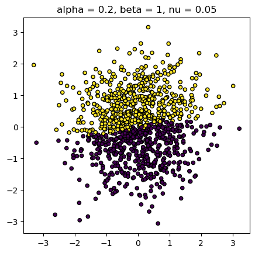

```python
alpha, beta, nu = 0.2, 1, 0.05
X1, y1 = createData(alpha, beta, nu)
plot_dataset(X1, y1, alpha, beta, nu)
```

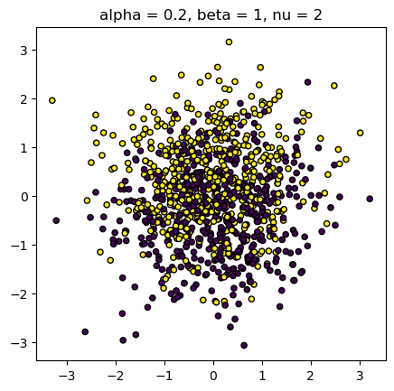

```python
alpha, beta, nu = 0.2, 1, 2
X2, y2 = createData(alpha, beta, nu)
plot_dataset(X2, y2, alpha, beta, nu)
```

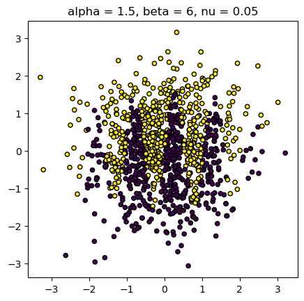

```python
alpha, beta, nu = 1.5, 6, 0.05
X3, y3 = createData(alpha, beta, nu)
plot_dataset(X3, y3, alpha, beta, nu)
```

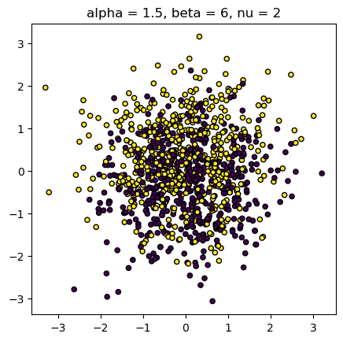

```python
alpha, beta, nu = 1.5, 6, 2
X4, y4 = createData(alpha, beta, nu)
plot_dataset(X4, y4, alpha, beta, nu)
```

#### 1.1.2

`n_estimators` defines how many decision trees are made in the random forest. Larger number of trees tends to improve the model's performance as it reduces the risk of overfitting. But using more trees will increase the training time, since the model has to train more individual trees.

(Used Chatgpt on grammar)

#### 1.1.3

```python
## DBplot from textbook
def DBPlot(m, X, y, nGrid = 100):
    ## find the extent of the features
    ## and add 'padding', here "1" to it.  Adjust as needed!
    x1_min, x1_max = X[:, 0].min() - 1, X[:, 0].max() + 1
            # note: indexing assumes X is a np.array!
    x2_min, x2_max = X[:, 1].min() - 1, X[:, 1].max() + 1
    ## make a dense grid (nGrid x nGrid) in this extent
    xx1, xx2 = np.meshgrid(np.linspace(x1_min, x1_max, nGrid),
                           np.linspace(x2_min, x2_max, nGrid))
    ## Convert two grids into two columns
    XX = np.column_stack((xx1.ravel(), xx2.ravel()))
    ## predict on the grid
    hatyy = m.predict(XX).reshape(xx1.shape)
    plt.figure(figsize=(8,8))
    ## show the predictions as an semi-transparent image
    _ = plt.imshow(hatyy, extent=(x1_min, x1_max, x2_min, x2_max),
                   aspect="auto",
                   interpolation='none', origin='lower',
                   alpha=0.3)
    ## add the actual data points on the image
    plt.scatter(X[:,0], X[:,1], c=y, s=30, edgecolors='k')
    plt.xlim(x1_min, x1_max)
    plt.ylim(x2_min, x2_max)
    plt.show()
```

```python
def experiment(X, y, n_value):
    # (a)
    Xt, Xv, yt, yv = train_test_split(X, y, test_size=0.2, random_state=371)

    best_acc = 0
    best_n = None
    best_model = None

    # (b)
    for n in n_value:
        clf = RandomForestClassifier(n_estimators=n, random_state=371)
        clf.fit(Xt, yt)
        y_pred = clf.predict(Xv)
        acc = accuracy_score(yv, y_pred)
        print(f"n = {n}, accuracy = {acc}")
        if acc > best_acc:
            best_acc = acc
            best_n = n
            best_model = clf

    # (c)
    print(f"Best n = {best_n}, accuracy = {best_acc}")

    # (d)
    DBPlot(best_model, Xv, yv)
```

```
Experiment 1
===================================
alpha = 0.2, beta = 1, nu = 0.05
===================================
n = 10, accuracy = 0.96
n = 100, accuracy = 0.95
n = 200, accuracy = 0.95
n = 300, accuracy = 0.95
n = 400, accuracy = 0.95
n = 500, accuracy = 0.95
n = 600, accuracy = 0.95
n = 700, accuracy = 0.95
n = 800, accuracy = 0.95
n = 900, accuracy = 0.95
n = 1000, accuracy = 0.95
Best n = 10, accuracy = 0.96
```

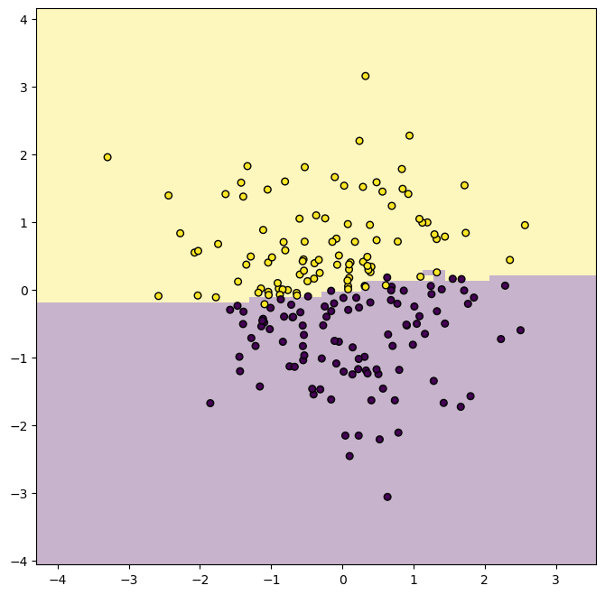

```
Experiment 2
===================================
alpha = 0.2, beta = 1, nu = 2
===================================
n = 10, accuracy = 0.575
n = 100, accuracy = 0.6
n = 200, accuracy = 0.615
n = 300, accuracy = 0.61
n = 400, accuracy = 0.605
n = 500, accuracy = 0.61
n = 600, accuracy = 0.615
n = 700, accuracy = 0.615
n = 800, accuracy = 0.615
n = 900, accuracy = 0.615
n = 1000, accuracy = 0.615
Best n = 200, accuracy = 0.615
```

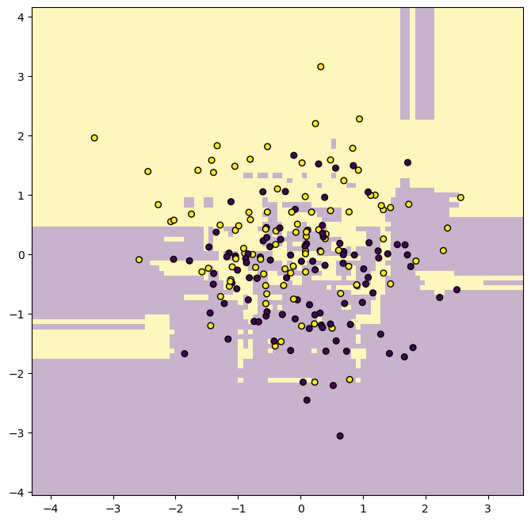

```
Experiment 3
===================================
alpha = 1.5, beta = 6, nu = 0.05
===================================
n = 10, accuracy = 0.93
n = 100, accuracy = 0.945
n = 200, accuracy = 0.945
n = 300, accuracy = 0.94
n = 400, accuracy = 0.95
n = 500, accuracy = 0.94
n = 600, accuracy = 0.94
n = 700, accuracy = 0.94
n = 800, accuracy = 0.94
n = 900, accuracy = 0.94
n = 1000, accuracy = 0.94
Best n = 400, accuracy = 0.95
```

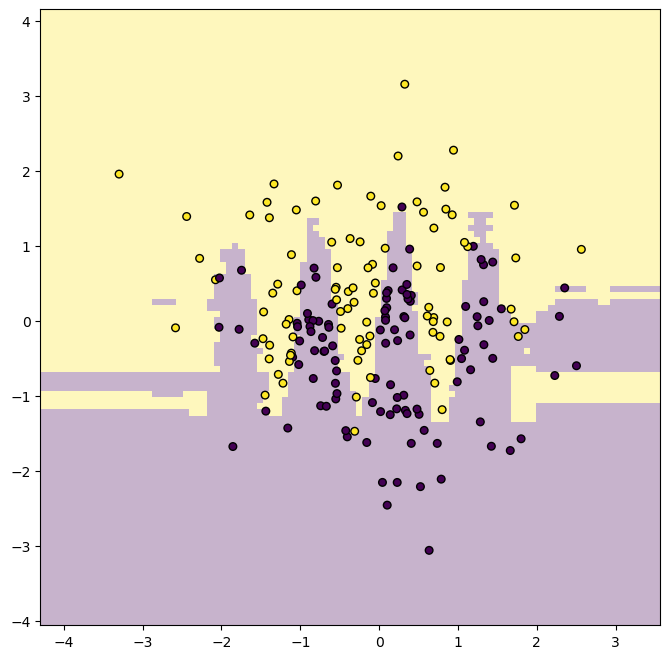

```
Experiment 4
===================================
alpha = 1.5, beta = 6, nu = 2
===================================
n = 10, accuracy = 0.645
n = 100, accuracy = 0.645
n = 200, accuracy = 0.645
n = 300, accuracy = 0.645
n = 400, accuracy = 0.65
n = 500, accuracy = 0.65
n = 600, accuracy = 0.655
n = 700, accuracy = 0.655
n = 800, accuracy = 0.65
n = 900, accuracy = 0.65
n = 1000, accuracy = 0.655
Best n = 600, accuracy = 0.655
```

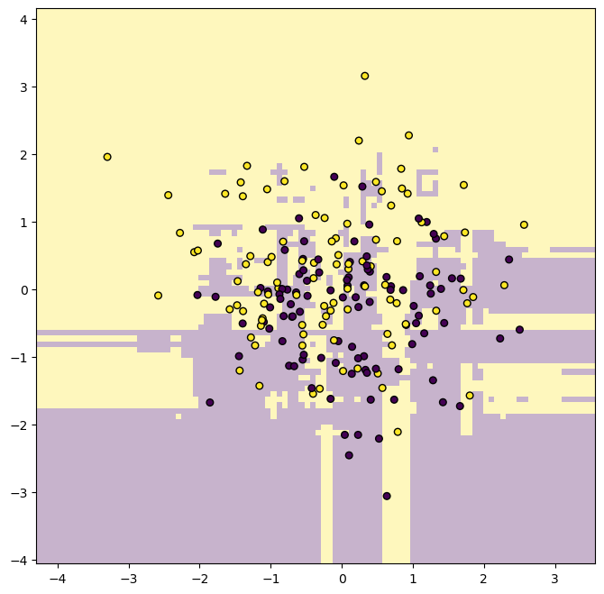

```python
n_value = [10, 100, 200, 300, 400, 500, 600, 700, 800, 900, 1000]
print("Experiment 1")
print("===================================")
print("alpha = 0.2, beta = 1, nu = 0.05")
print("===================================")
experiment(X1, y1, n_value)
print("Experiment 2")
print("===================================")
print("alpha = 0.2, beta = 1, nu = 2")
print("===================================")
experiment(X2, y2, n_value)
print("Experiment 3")
print("===================================")
print("alpha = 1.5, beta = 6, nu = 0.05")
print("===================================")
experiment(X3, y3, n_value)
print("Experiment 4")
print("===================================")
print("alpha = 1.5, beta = 6, nu = 2")
print("===================================")
experiment(X4, y4, n_value)
```

#### 1.1.4

- For simple data with low noise, the number of estimator is 10 which is pretty low. Model can reach good accuracy quickly.
- For simple data with more noise, the number of estimator is 200 which is more than the one with no noise. Noise increase the number of estimator needed.
- For complex data with low noise, the number of estimator is 400 which is much more than simple data with low noise.
- For complex data with more noise, the number of estimator is 600 which is much more than complex data with low noise.

Summary: more complex data need more number of estimators. Higher noise need more number of estimators as well and it reduces the accuracy.

### 1.2

#### 1.2.1

```python
tw = pd.read_csv("../../data/tw-bankruptcy.csv.bz2")
X = tw.drop(columns=["Bankrupt?"]).values
y = tw["Bankrupt?"].values
```

#### 1.2.2

```python
n_value = [1, 100, 200, 300, 400, 500, 600, 700, 800, 900, 1000]

train_acc_list = []
val_acc_list = []

def experiment(X, y, n_values):
    Xt, Xv, yt, yv = train_test_split(X, y, test_size=0.2, random_state=371)

    best_acc = 0
    best_n = None
    best_model = None

    for n in n_values:
        clf = RandomForestClassifier(n_estimators=n, random_state=42)
        clf.fit(Xt, yt)

        y_train_pred = clf.predict(Xt)
        y_val_pred = clf.predict(Xv )

        train_acc = accuracy_score(yt, y_train_pred)
        val_acc = accuracy_score(yv, y_val_pred)

        train_acc_list.append(train_acc)
        val_acc_list.append(val_acc)

        print(f"n = {n}, train acc = {train_acc}, val acc = {val_acc}")

        if val_acc > best_acc:
            best_acc = val_acc
            best_n = n
            best_model = clf

    print(f"Best n = {best_n}, val acc = {best_acc}")
```

```python
experiment(X, y, n_value)
```

```
n = 1, train acc = 0.9820348304307974, val acc = 0.9545454545454546
n = 100, train acc = 0.9998166819431714, val acc = 0.9743401759530792
n = 200, train acc = 1.0, val acc = 0.9750733137829912
n = 300, train acc = 1.0, val acc = 0.9743401759530792
n = 400, train acc = 1.0, val acc = 0.9736070381231672
n = 500, train acc = 1.0, val acc = 0.9743401759530792
n = 600, train acc = 1.0, val acc = 0.9743401759530792
n = 700, train acc = 1.0, val acc = 0.9743401759530792
n = 800, train acc = 1.0, val acc = 0.9743401759530792
n = 900, train acc = 1.0, val acc = 0.9736070381231672
n = 1000, train acc = 1.0, val acc = 0.9743401759530792
Best n = 200, val acc = 0.9750733137829912
```

#### 1.2.3

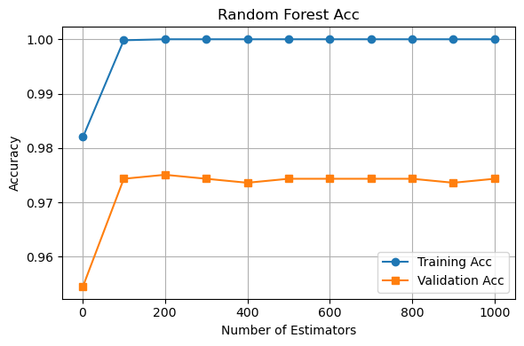

```python
plt.figure(figsize=(6, 4))
plt.plot(n_value, train_acc_list, label='Training Acc', marker='o')
plt.plot(n_value, val_acc_list, label='Validation Acc', marker='s')
plt.xlabel("Number of Estimators")
plt.ylabel("Accuracy")
plt.title("Random Forest Acc")
plt.legend()
plt.grid(True)
plt.tight_layout()
plt.show()
```

#### 1.2.4

Best n = 200, val acc = 0.9750733137829912

## 2

### 2.1

#### 2.1.1

- a

$$ = \begin{bmatrix} 0 * 1 + 0 * 4 & 0 * 0 + 4 * -1 \\ 5 * 1 + 3 * 0 & 5 * 0 + 3 * -1 \end{bmatrix} = \begin{bmatrix} 0 & -4 \\ 5 & -3 \end{bmatrix} $$

- b

Left part 2x2, right part 3x2. Can't perform this multiplication.

- c (2x3)

$$ = \begin{bmatrix} 0 * 1 + 6 * 0 & 0 * 0 + 6 * -1 & 0 * 0 + 6 * 1\\ 5 * 1 + 3 * 0 & 5 * 0 + 3 * -1 & 5 * 0 + 3 * 1 \\ \end{bmatrix} = \begin{bmatrix} 0 & -6 & 6\\ 5 & -3 & 3\\ \end{bmatrix} $$

### 2.2

#### 2.2.1

```python
def matrix_product(A, B):
    # Dim check
    m, n = A.shape
    n2, b = B.shape

    if n != n2:
        return "Matrix dimension not match"
    else:
        result = np.zeros((m, b))

        for i in range(m):
            for j in range(b):
                for k in range(n):
                    result[i, j] += A[i, k] * B[k, j]

        return result.astype(int)
```

#### 2.2.2

```python
A = np.array([[0, 4], [5, 3]])
B = np.array([[1, 0], [0, -1]])
C = np.array([[0, 6], [5, 3]])
D = np.array([[1, 0], [0, -1], [0, 1]])

print("QA = \n", matrix_product(A, B), "\n")
print("QB = \n", matrix_product(C, D), "\n")
print("QC = \n", matrix_product(C, D.T), "\n")
```

```
QA =
 [[ 0 -4]
 [ 5 -3]]

QB =
 Matrix dimension not match

QC =
 [[ 0 -6  6]
 [ 5 -3  3]]
```

Matched my calculation.

## 3

### 3.1

```python
ch = pd.read_csv("../../data/crazy-hat.tsv", sep="\t")
ch.head()
```

|  | x | y | group |
| --- | --- | --- | --- |
| 0 | 0 | 22 | outline |
| 1 | 16 | -18 | outline |
| 2 | -16 | -18 | outline |
| 3 | 0 | 22 | outline |
| 4 | -3 | 7 | leye |

### 3.2

```python
X = ch[["x", "y"]].values
groups = ch["group"].values
```

### 3.3

Rotation should only affects the position of point (coordinates), not grouping because grouping is just for defining how to connect points.

### 3.4

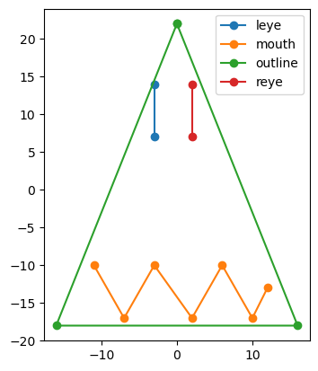

```python
ax = plt.axes()
ax.set_aspect("equal")
unique_groups = np.unique(groups)

for group in unique_groups:
    indices = (groups == group)
    segment = X[indices]
    ax.plot(segment[:, 0], segment[:, 1], marker='o', label=group)

plt.legend()
plt.show()
```

### 3.5

```python
def plot(X, groups, title=""):
    ax = plt.axes()
    ax.set_aspect("equal")
    unique_groups = np.unique(groups)

    for group in unique_groups:
        indices = (groups == group)
        segment = X[indices]
        ax.plot(segment[:, 0], segment[:, 1], marker='o', label=group)

    plt.legend()
    plt.show()
```

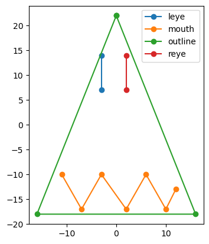

```python
plot(X, groups, title="Original Crazy Hat")
```

### 3.6

```python
def Rot(alpha_degrees):
    alpha = np.pi * alpha_degrees / 180
    return np.array([
        [np.cos(alpha), -np.sin(alpha)],
        [np.sin(alpha),  np.cos(alpha)]
    ])
```

### 3.7

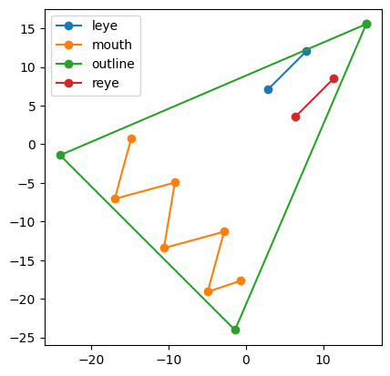

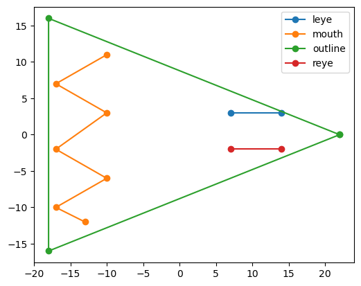

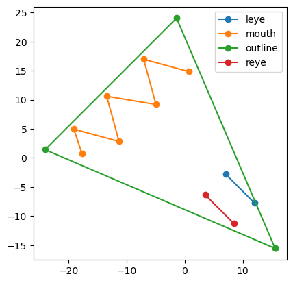

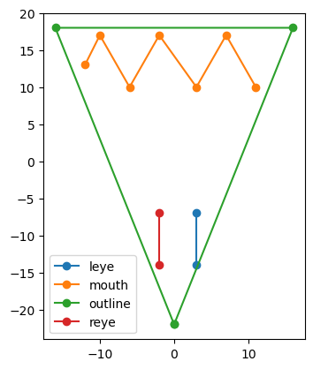

```python
for angle in [45, 90, 135, 180]:
    XR = X @ Rot(angle)
    plot(XR, groups, title=f"{angle} degrees rotation")
```

## 4

### 4.1

```python
boston = pd.read_csv("../../data/boston.csv.bz2", sep="\t")
```

```python
boston.head()
```

[output not shown]

### 4.2

```python
import statsmodels.api as sm
```

```python
X_vars = ["rm", "lstat", "zn"]
X = boston[X_vars]
X = sm.add_constant(X)
y = boston["medv"]

model = sm.OLS(y, X).fit()
print(model.summary())
```

```
                            OLS Regression Results
==============================================================================
Dep. Variable:                   medv   R-squared:                       0.640
Model:                            OLS   Adj. R-squared:                  0.638
Method:                 Least Squares   F-statistic:                     297.3
Date:                Thu, 24 Apr 2025   Prob (F-statistic):          6.65e-111
Time:                        02:27:08   Log-Likelihood:                -1581.8
No. Observations:                 506   AIC:                             3172.
Df Residuals:                     502   BIC:                             3189.
Df Model:                           3
Covariance Type:            nonrobust
==============================================================================
                 coef    std err          t      P>|t|      [0.025      0.975]
------------------------------------------------------------------------------
const         -1.4606      3.171     -0.461      0.645      -7.691       4.770
rm             5.0455      0.446     11.324      0.000       4.170       5.921
lstat         -0.6240      0.046    -13.644      0.000      -0.714      -0.534
zn             0.0158      0.012      1.359      0.175      -0.007       0.039
==============================================================================
Omnibus:                      150.432   Durbin-Watson:                   0.824
Prob(Omnibus):                  0.000   Jarque-Bera (JB):              487.567
Skew:                           1.376   Prob(JB):                    1.34e-106
Kurtosis:                       6.943   Cond. No.                         343.
==============================================================================

Notes:
[1] Standard Errors assume that the covariance matrix of the errors is correctly specified.
```

### 4.3

```python
X_matrix = np.column_stack((
    np.ones(len(boston)),
    boston["rm"].values,
    boston["lstat"].values,
    boston["zn"].values
))
```

### 4.4

```python
y_vector = boston["medv"].values
```

### 4.5

```python
Xt = X_matrix.T
XtX = Xt @ X_matrix
XtX_inv = np.linalg.inv(XtX)
Xty = Xt @ y_vector

beta = XtX_inv @ Xty
beta
```

```
array([-1.46057734,  5.04554308, -0.62401045,  0.01580778])
```

### 4.6

Yes they matches.

### Hour Spent: 3h